# US Census Demographic Data

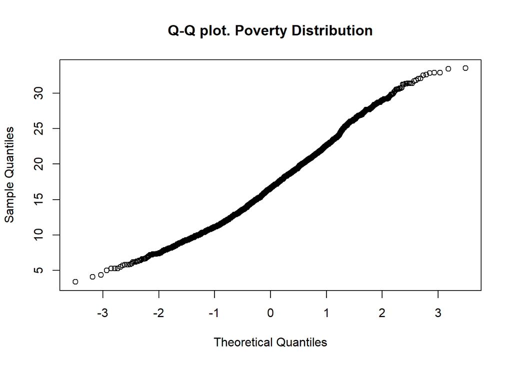

```r
#3 Graph for Poverty
 qqnorm(Adata9$Poverty,main = "Q-Q plot. Poverty Distribution")
```

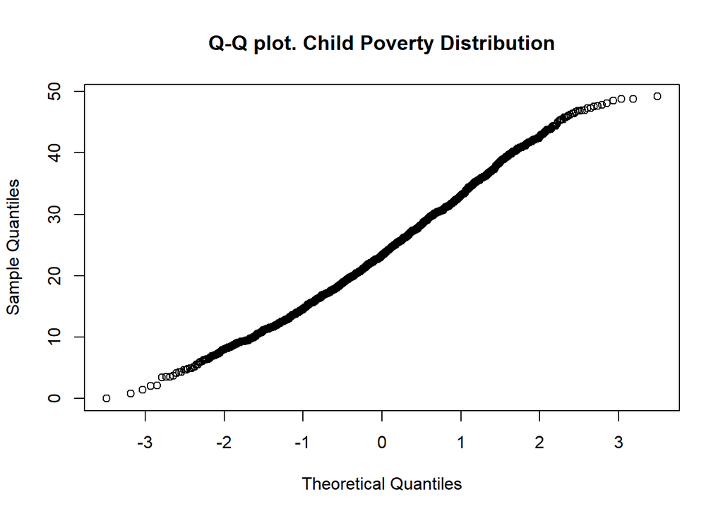

```r
#4 Graph for child poverty
 qqnorm(Adata9$ChildPoverty,main = "Q-Q plot. Child Poverty Distribution")
```

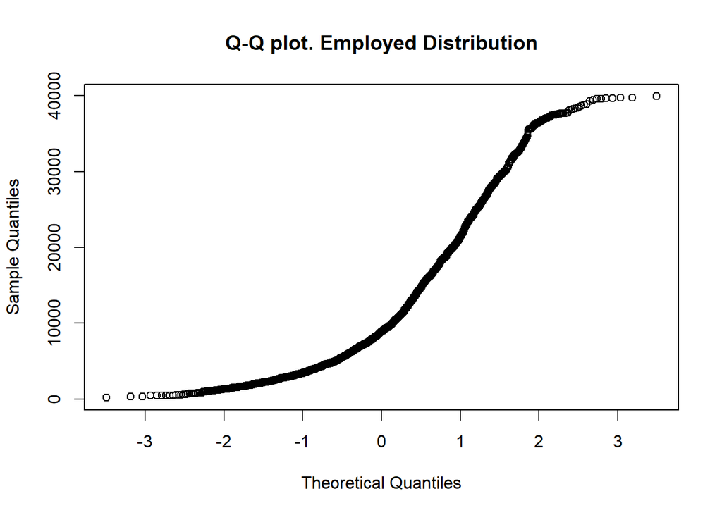

```r
 #5 Graph for Employed
 qqnorm(Adata9$Employed,main = "Q-Q plot. Employed Distribution")
```

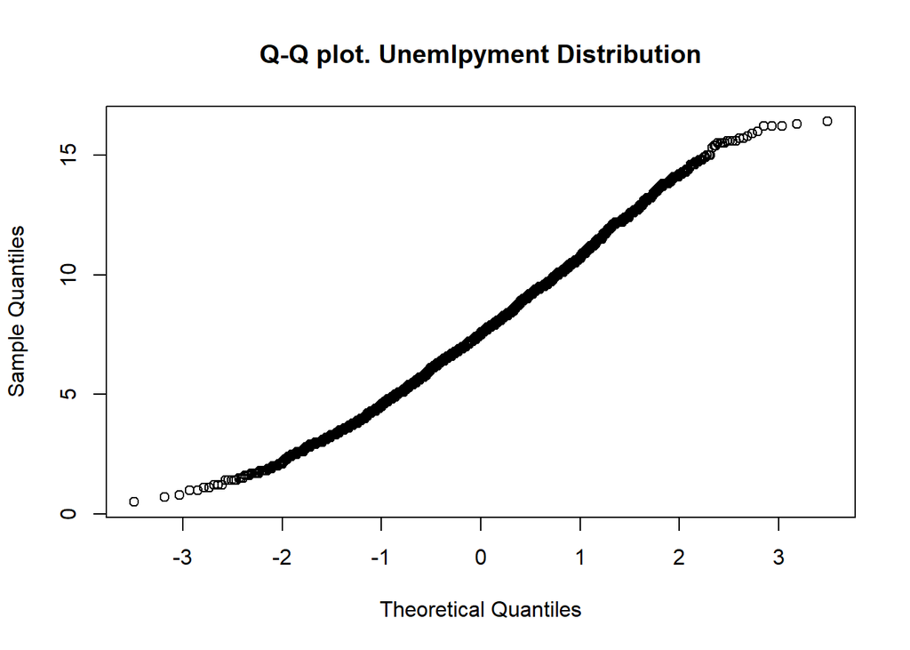

```r
#6 Graph for unemployment
 qqnorm(Adata9$Unemployment,main = "Q-Q plot. Unemlpyment Distribution")
```

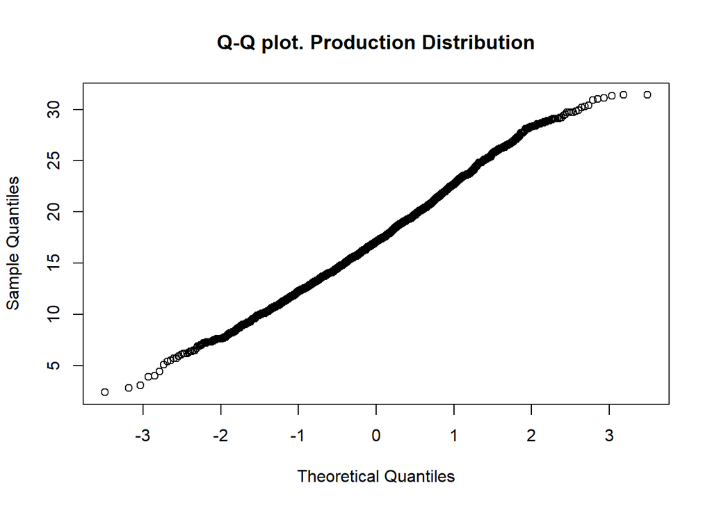

```r
 #7 Graph for Production
 qqnorm(Adata9$Production,main = "Q-Q plot. Production Distribution")
```

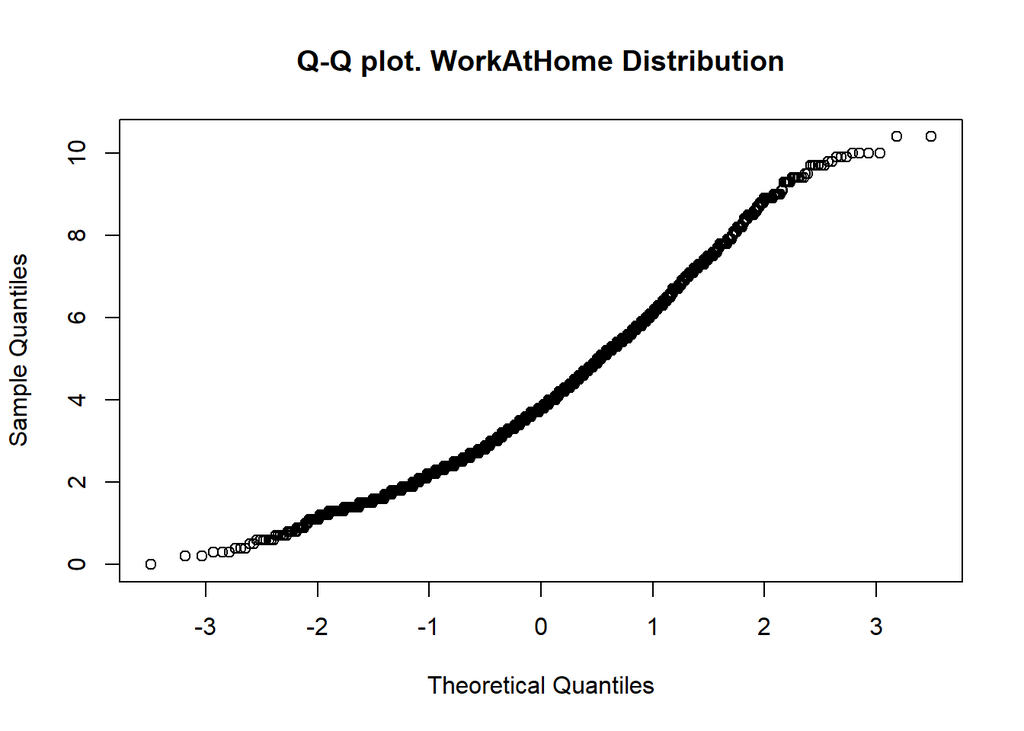

```r
 #8 Graph for WorkAtHome
 qqnorm(Adata9$WorkAtHome,main = "Q-Q plot. WorkAtHome Distribution")
```

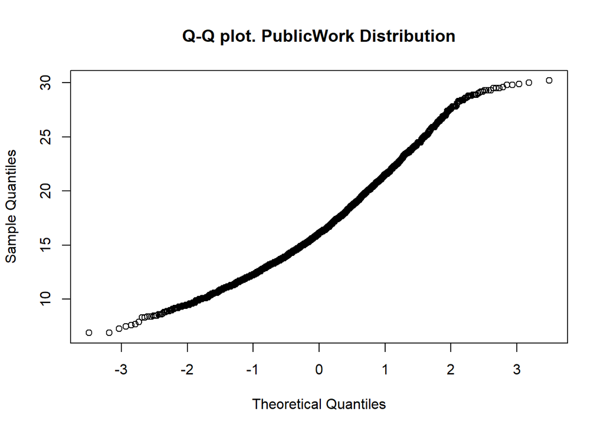

```r
#9 Graph for PublicWork
 qqnorm(Adata9$PublicWork,main = "Q-Q plot. PublicWork Distribution")
```

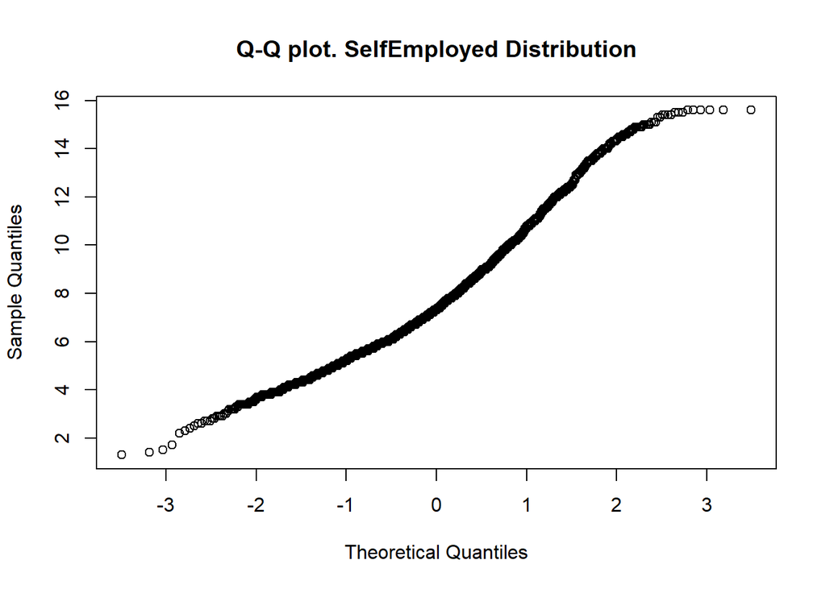

```r
 #10 Graph for SelfEmployed
 qqnorm(Adata9$SelfEmployed,main = "Q-Q plot. SelfEmployed Distribution")
```

**Our conclusion:**

**From these graphs, we noticed that the columns that use rates instead of total number are normally distributed like: income, poverty,child poverty, unemployment, Production,WorkAtHome,PublicWork, SelfEmployed.While the columns that use total numbers are not normally distributed like: Total population and Employed columns.** **The columns that we need them for our tests are normally distributed, so we are good to go!**

### Chapter 4: Graphs and relationship

**What factors affect poverty in counties?**

Graphical or Realistic representation is another way of dissecting numerical information. A graphical representation may be a sort of chart through which factual information are spoken to within the frame of lines or bends drawn over the facilitated focuses plotted on its surface. Similarly, we have worked on different graphs to show different possible conditions and reason to show major reasons of increasing poverty.

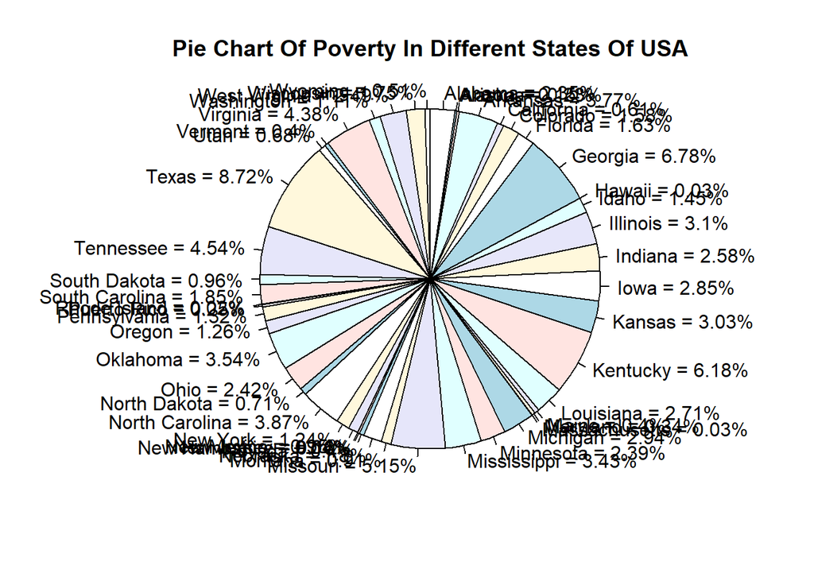

```r
#7. What factors affect poverty in counties?

loadPkg("ggplot2")
loadPkg("gridExtra")
loadPkg("ggcorrplot")
xkablesummary(Adata9)

# Poverty in different states
State_fact<-as.factor(Adata9$State)
Check<-aggregate(x= Adata9$Poverty, by= list(Adata9$State),FUN= sum)
Check
sum(Check$x)
pie_labels <- paste0(Check$Group.1, " = ", round(100 * Check$x/sum(Check$x), 2), "%")
population_pie_Chart = pie(Check$x,labels = pie_labels, radius=1, main="Pie Chart Of Poverty In Different States Of USA", clockwise = TRUE)
```

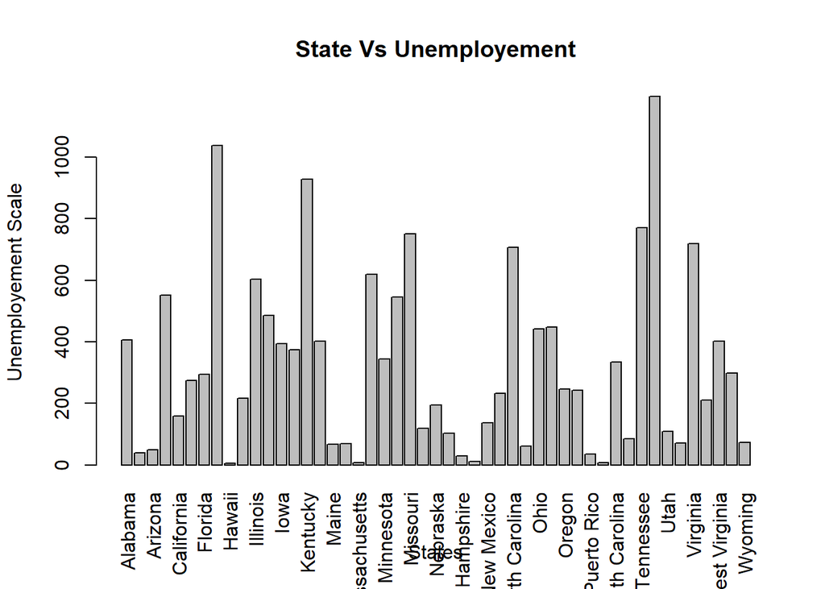

```r
library(ggplot2)

#factors affecting poverty

#1. unemployement

Check2<-aggregate(x=Adata9$Unemployment, by= list(Adata9$State), FUN= sum)
Check2

#barplot(Check2$x, main = "State Vs Unemployement", names.arg = Check2$Group.1, xlab = "States", ylab = "Unemployement Scale", angle = 90, cey.axis = 1)
Unemployment_Bar_graph<-barplot(Check2$x,names.arg = Check2$Group.1, xlab = "States", ylab = "Unemployement Scale",  main = "State Vs Unemployement", las = 3)
```

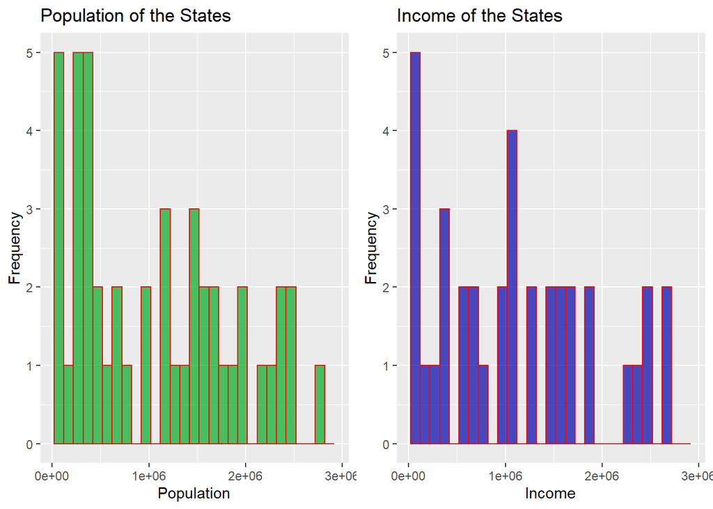

```r
#2. population and income

Check3<-aggregate(x=Adata9$TotalPop, by= list(Adata9$State), FUN= sum)
Check3


histPop <- ggplot(data=Check3, aes(x)) +
  geom_histogram(breaks=seq(20000, 3000000, by = 100000),
                 col="red",
                 fill="#00aa22",
                 alpha = .7) + # opacity
  labs(title="Population of the States") +
  labs(x="Population", y="Frequency")

Check4<-aggregate(x=Adata9$Income, by= list(Adata9$State), FUN= sum)
Check4

histIncome <- ggplot(data=Check4, aes(x)) +
  geom_histogram(breaks=seq(20000, 3000000, by = 100000),
                 col="red",
                 fill="#0000aa",
                 alpha = .7) + # opacity
  labs(title="Income of the States") +
  labs(x="Income", y="Frequency")

grid.arrange(histPop, histIncome, ncol=2, nrow=1)
```

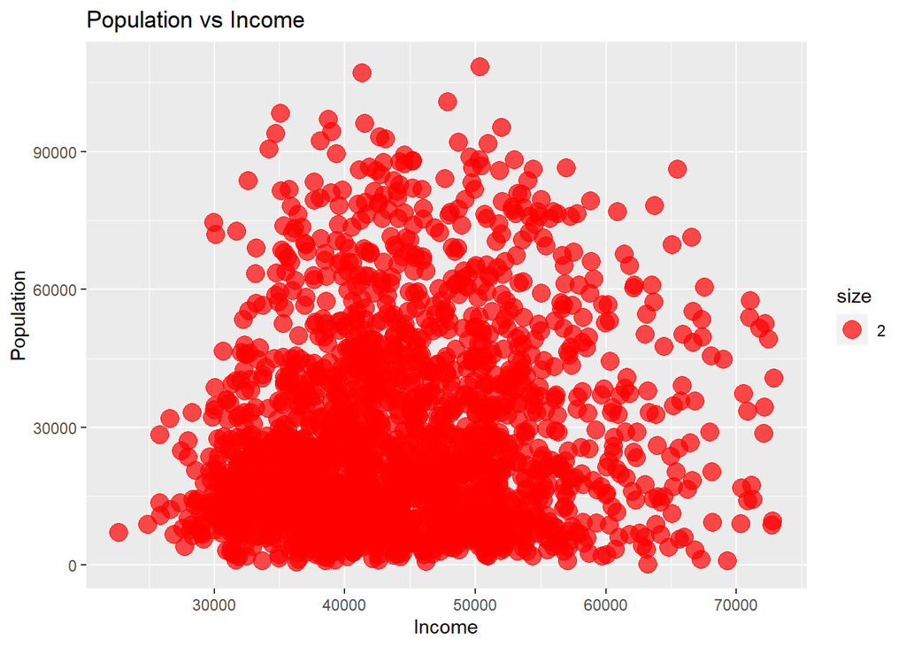

```r
#3. Impact of unemployement, population and income on Poverty
Income_pop <- ggplot(Adata9) +
    geom_point(aes(x = Income , y = TotalPop, size = 2 ), alpha = 0.7 , col = "red" )+labs(title = "Population vs Income")+labs(x="Income", y="Population" )

Unemployment_Pop <- ggplot(Adata9) +
    geom_point(aes(x = Unemployment , y = TotalPop, size = 2), alpha = 0.7, col = "red")+labs(title = "Population vs Unemployement")+labs(x="Unemployement", y="Population" )

Income_pop
```

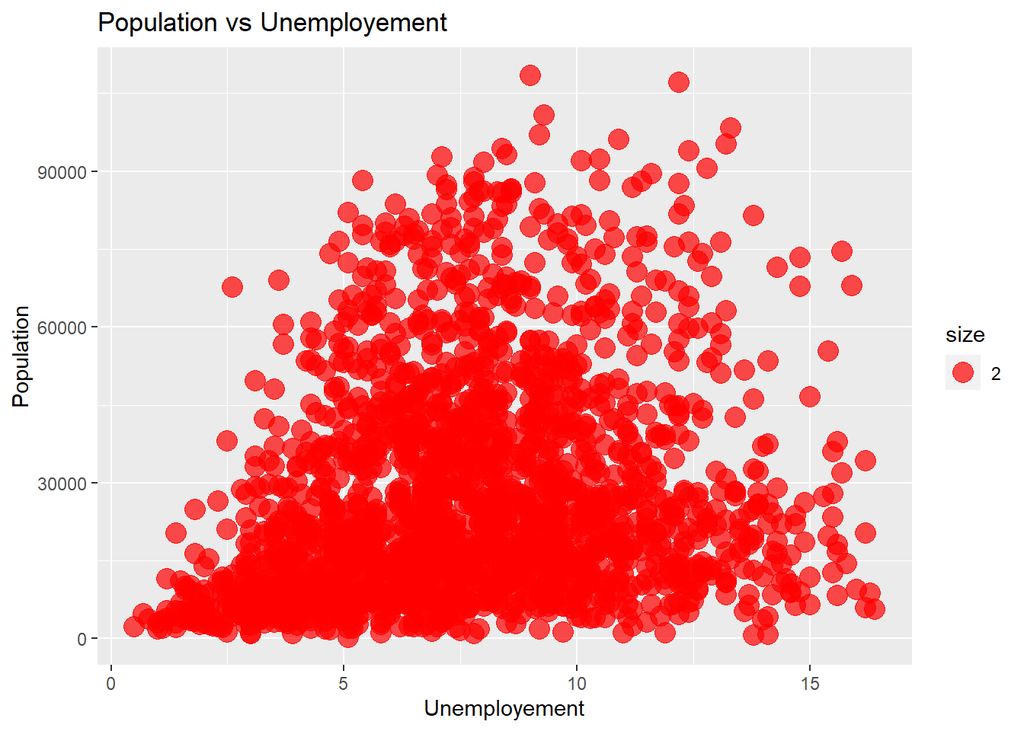

```r
Unemployment_Pop
```

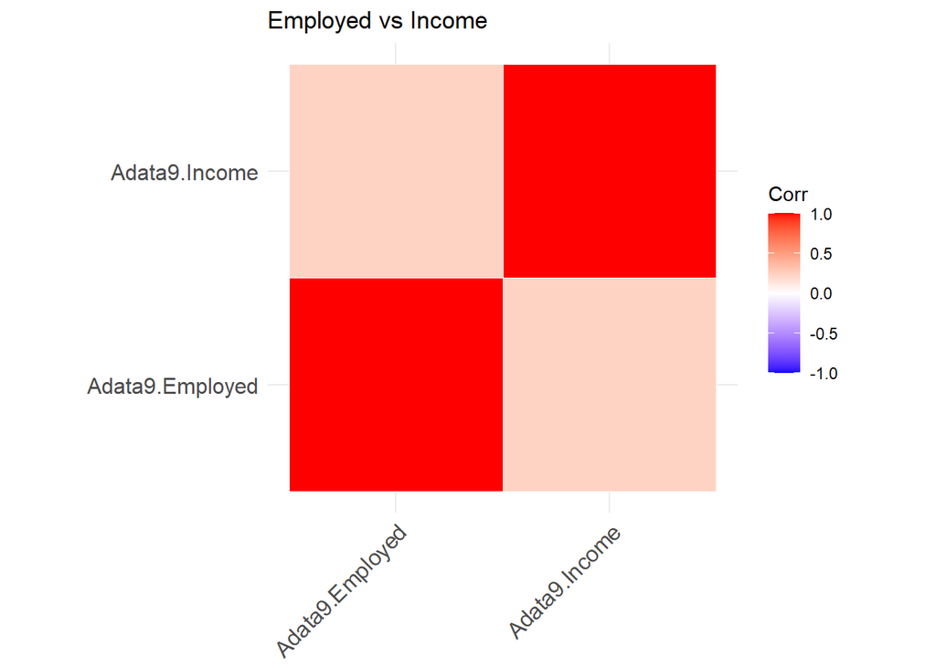

```r
#Correlation employed vs Income

library(ggcorrplot)

Check5 <- data.frame(Adata9$Employed,Adata9$Income)

corr <- round(cor(Check5), 3)
ggcorrplot(corr, hc.order = TRUE, outline.col = "white")+labs(title = "Employed vs Income")+labs(x="Employed", y="Income" )
```

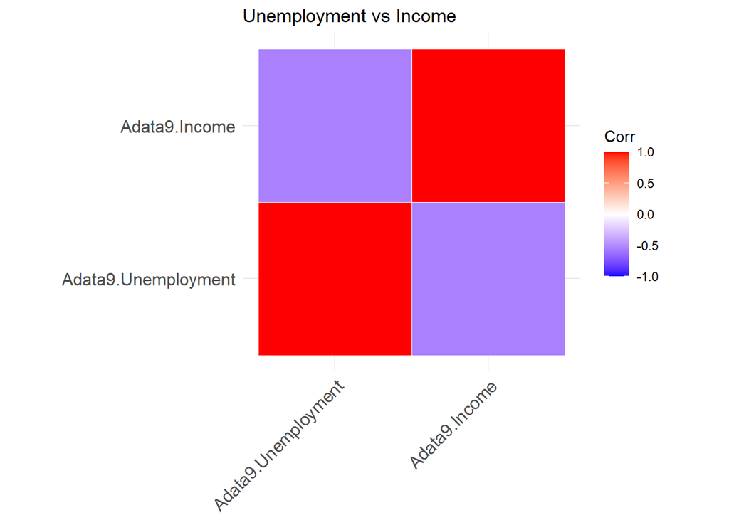

```r
#Correlation unemployement vs Income

Check6<- data.frame(Adata9$Unemployment,Adata9$Income)

corr <- round(cor(Check6), 3)
ggcorrplot(corr, hc.order = TRUE, outline.col = "white")+labs(title = "Unemployment vs Income")+labs(x="Unemployment", y="Income" )
```

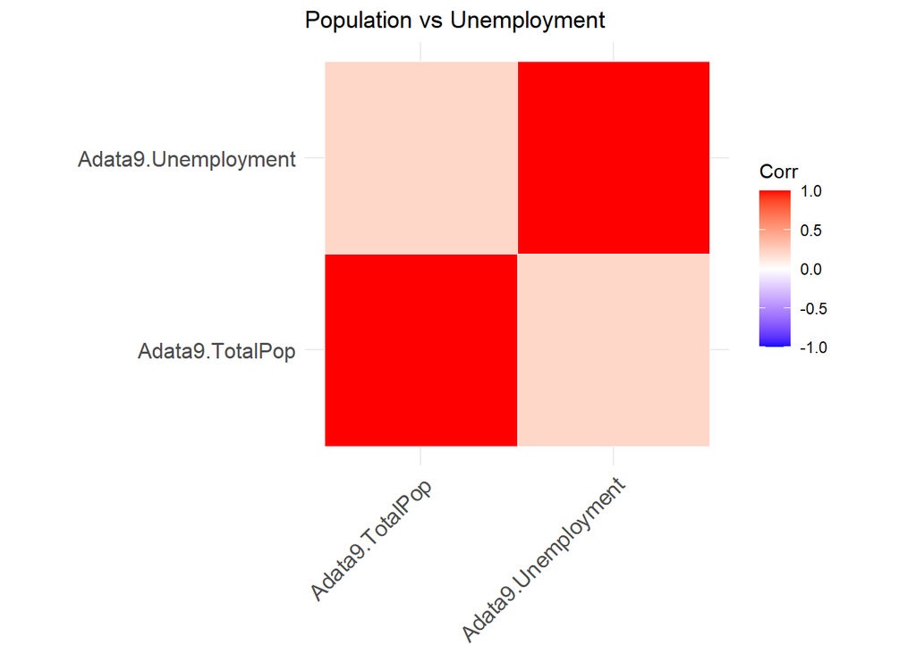

```r
#Correlation population vs unemployement

Check7<- data.frame(Adata9$TotalPop,Adata9$Unemployment)

corr <- round(cor(Check7), 3)
ggcorrplot(corr, hc.order = TRUE, outline.col = "white")+labs(title = "Population vs Unemployment")+labs(x="Population", y="Unemployment" )
```

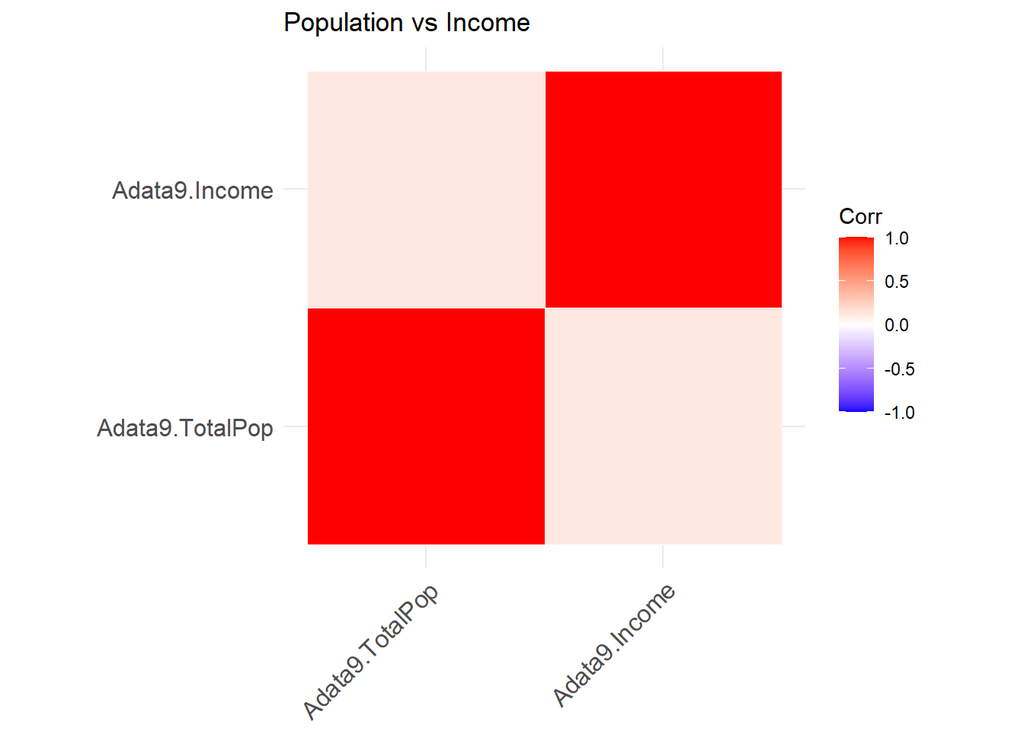

```r
#Correlation population vs Income

Check8<- data.frame(Adata9$TotalPop,Adata9$Income)

corr <- round(cor(Check8), 3)
ggcorrplot(corr, hc.order = TRUE, outline.col = "white")+labs(title = "Population vs Income")+labs(x="Population", y="Income" )
```

### Chapter 5: Tests

**tests and results**

First, let’s start to get a general idea of how poverty relates to all the factors by looking at the correlation matrix between ‘Poverty’ and the other variables.

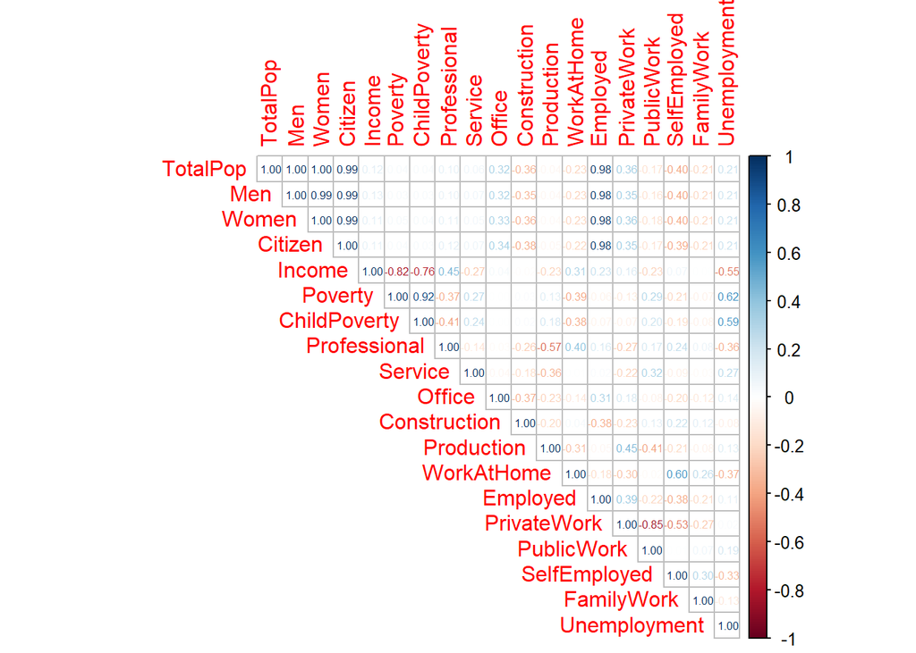

As long as all the variables listed above are checked to be normality distributed in Chapter 3, we are able to perform tests directly on them. Since the independent variables and the dependent variable ‘Poverty’ are all quantitative, t-test would be the best choice to test the hypothesis.

We will now perform a two sample t-test to see if the counties with different income have different poverty. To setup, we divide the data into two parts (one with income values above the average income, the other with income values below average income) and take a sample of size 50, we set our $\alpha$ value as 0.05,and our hypothesis as:

$H_0$: $\mu_{upper}=\mu_{lower}$, the two sub-datasets have the same average poverty. $H_1$: $\mu_{upper}\neq\mu_{lower}$, the two sub-datasets do not have the same average poverty.

```
##
##  Welch Two Sample t-test
##
## data:  iu_sample$Poverty and il_sample$Poverty
## t = -11, df = 94, p-value <2e-16
## alternative hypothesis: true difference in means is not equal to 0
## 95 percent confidence interval:
##  -10.26  -7.09
## sample estimates:
## mean of x mean of y
##      12.2      20.9
```

Since the p-value we got from the t-test is $2*10^{-16}$ which is smaller than a $\alpha$ value of 0.05, we have sufficient evidence to reject $H_0$ and conclude that there is a difference between the mean poverty for the two groups. Thus, ‘poverty’ is affected by ‘Income’.

```
##
##  Welch Two Sample t-test
##
## data:  pu_sample$Poverty and pl_sample$Poverty
## t = -4, df = 98, p-value = 2e-04
## alternative hypothesis: true difference in means is not equal to 0
## 95 percent confidence interval:
##  -5.38 -1.70
## sample estimates:
## mean of x mean of y
##      14.9      18.4
```

P-value for ‘Professional’ is $2*10^{-4}$ which is less than 0.05, we reject the null and state that ‘Professional’ is a affecting factor on ‘Poverty’.

```
##
##  Welch Two Sample t-test
##
## data:  su_sample$Poverty and sl_sample$Poverty
## t = 3, df = 96, p-value = 0.004
## alternative hypothesis: true difference in means is not equal to 0
## 95 percent confidence interval:
##  1.09 5.60
## sample estimates:
## mean of x mean of y
##      19.6      16.3
```

P-value for ‘Service’ is 0.004 which is smaller than 0.05, we reject the null and state that ‘Service’ is an affecting factor for ‘Poverty’.

```
##
##  Welch Two Sample t-test
##
## data:  produ_sample$Poverty and prodl_sample$Poverty
## t = 1, df = 97, p-value = 0.2
## alternative hypothesis: true difference in means is not equal to 0
## 95 percent confidence interval:
##  -0.888  3.952
## sample estimates:
## mean of x mean of y
##      17.7      16.1
```

P-value for ‘Production’ is 0.2 which is greater than 0.05, we can not reject $H_0$, and can not conclude that ‘Production’ is an affecting factors for ‘Poverty’.

```
##
##  Welch Two Sample t-test
##
## data:  wu_sample$Poverty and wl_sample$Poverty
## t = -5, df = 92, p-value = 4e-07
## alternative hypothesis: true difference in means is not equal to 0
## 95 percent confidence interval:
##  -6.84 -3.20
## sample estimates:
## mean of x mean of y
##      13.6      18.6
```

P-value for “WorkAtHome’ is extremely small, we have sufficient evidence to state that”WorkAtHome’ is an effecting factor for ‘Poverty’.

```
##
##  Welch Two Sample t-test
##
## data:  pubu_sample$Poverty and publ_sample$Poverty
## t = 2, df = 93, p-value = 0.02
## alternative hypothesis: true difference in means is not equal to 0
## 95 percent confidence interval:
##  0.482 4.378
## sample estimates:
## mean of x mean of y
##      17.8      15.3
```

```
##
##  Welch Two Sample t-test
##
## data:  semu_sample$Poverty and seml_sample$Poverty
## t = -2, df = 94, p-value = 0.1
## alternative hypothesis: true difference in means is not equal to 0
## 95 percent confidence interval:
##  -4.22  0.42
## sample estimates:
## mean of x mean of y
##      16.3      18.2
```

P-value for ‘SelfEmployment’ is 0.1 which is greater than 0.05, we can not reject $H_0$, so it is not an effecting factor for ‘Poverty’.

```
##
##  Welch Two Sample t-test
##
## data:  uemu_sample$Poverty and ueml_sample$Poverty
## t = 6, df = 98, p-value = 2e-07
## alternative hypothesis: true difference in means is not equal to 0
## 95 percent confidence interval:
##  3.85 8.02
## sample estimates:
## mean of x mean of y
##      20.3      14.3
```

P-value for ‘Unemployment’ is $2*10^{-7}$, so we have sufficient evidence to reject null and conclude that it is an effecting factor for ‘Poverty’.

Noticing that ‘State’ is left out from our correlation matrix since it is a categorical variable, we want to perform an ANOVA test to see if there’s difference in ‘Poverty’ across different states.

```
##               Df Sum Sq Mean Sq F value Pr(>F)
## State         48  27026     563    30.5 <2e-16 ***
## Residuals   2024  37417      18
## ---
## Signif. codes:  0 '***' 0.001 '**' 0.01 '*' 0.05 '.' 0.1 ' ' 1
```

As we can see in the results of ANOVA test, our p-value is extremely small, so we have sufficient evidence to reject the null and conclude that there is difference in ‘Poverty’ for different states. In this case, ‘State’ is an effecting factor for ‘Poverty’. Finally, we will perform a Post-hoc test to see the pairs of states that have different ‘Poverty’ as below. We will not display the result here since we not need this information to answer our SMART question, just save it for further analysis if needed.

### Chapter 6: Conclusion.

This dataset provided many insights into the dynamics of the US census demographic data. However, we were interested particularly in poverty and what are the factors that affect it. In order to answer our question, we performed data cleansing to prepare our dataset for EDA. Then, we perform normality test for 10 variables (our desired columns) to check if the data normally distributed. This is a necessary step, so we can use the normally distributed variables in tests that required such condition.